# Predicting readmission probability for diabetes inpatients, HW4 GROUP 18

Diego G. Dávila

Margaret Gardner

Joelle Bagautdinova

Due before midnight, March 20

# Instructions

- This is a project. Well organized and well presented write-up is one major motivation here. Please see the section on `Write up` for details.
- There is no single correct answer.
- The entire write up should not be more than **5** pages. All the R-codes should be hidden. Any R-output used should be formatted neatly. You may put all supporting documents, graphics, or other exhibits into an Appendix, which is not counted in the 5 page limit.

# Introduction

## Background

Diabetes is a chronic medical condition affecting millions of Americans, but if managed well, with good diet, exercise and medication, patients can lead relatively normal lives. However, if improperly managed, diabetes can lead to patients being continuously admitted and readmitted to hospitals. Readmissions are especially serious - they represent a failure of the health system to provide adequate support to the patient and are extremely costly to the system. As a result, the Centers for Medicare and Medicaid Services announced in 2012 that they would no longer reimburse hospitals for services rendered if a patient was readmitted with complications within 30 days of discharge.

Given these policy changes, being able to identify and predict those patients most at risk for costly readmissions has become a pressing priority for hospital administrators.

## Goal of the study

In this project, we shall explore how to use the techniques we have learned in order to help better manage diabetes patients who have been admitted to a hospital. Our goal is to avoid patients being readmitted within 30 days of discharge, which reduces costs for the hospital and improves outcomes for patients. If we could identify important factors relating to the chance of a patient being readmitted within 30 days of discharge, effective intervention could be done to reduce the chance of being readmitted. Also if we could predict one’s chance being readmitted well, actions can be taken.

As you all know, it is very important to present your findings well. To achieve the best possible results you need to understand your audience.

Your target audience is a manager within the hospital organization. They hold an MBA, are familiar with medical terminology (though you do not need any previous medical knowledge), and have gone through a similar course to our Modern Data Mining with someone like your professor. You can assume thus some level of technical familiarity, but should not let the paper be bogged down with code or other difficult to understand output.

Note then that the most important elements of your report are the clarity of your analysis and the quality of your proposals.

# Executive Summary

## Background

**Problem:** Diabetes is a chronic condition characterized by high blood sugar and is associated with important health concerns. In the U.S., diabetes is a major health care concern, as over 35 million (or 1 in 10) people are affected by this condition [CDC](https://www.cdc.gov/chronicdisease/programs-impact/pop/diabetes.htm). It also represents the nation’s most expensive chronic condition, with over 237 billion dollars being spent annually on care for individuals with diabetes. Importantly, if diabetes is not detected/managed poorly, this can lead to serious health conditions and may cause the patient to undergo repeated hospital admissions, which in turn involves substantial costs. In addition, insurances no longer reimburse hospitals when patients are readmitted within 30 days, creating a strong incentive for hospitals to improve initial admission care and understand which factors may increase the risk of readmission within 30 days.

## Brief data summary

To investigate factors associated with readmission within 30 days, we analyzed data from 71518 unique patients’ diabetes-related hospitalizations occurring between 1999 and 2008.Our dataset included: basic demographic information about the patients, such as age, gender and race; information about the hospitalization, such as what level of care they were admitted to and how long the were hospitalized for; counts of hospitalizations from the previous year; results from blood tests; changes in medications; and diagnoses.

Overall, around 7% of patients admitted to a hospital had to be readmitted within 30 days. This indicates suboptimal care during the first admission event, leading to poorer health outcomes and increasing the risk of repeated hospitalizations. This also represents a heavy financial burden for hospitals, given that healthcare for these 7% of patients is not reimbursed by insurances.

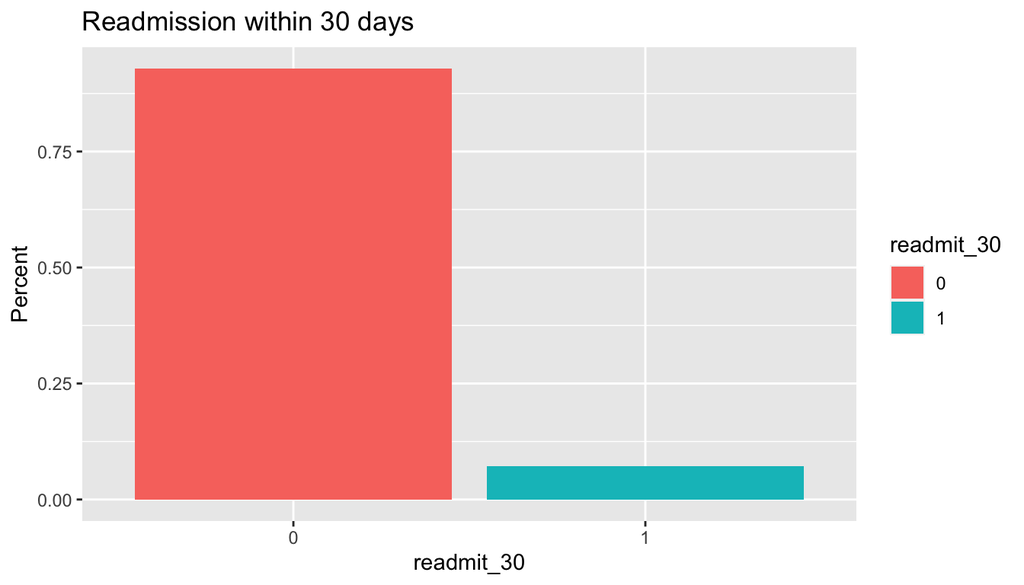

## Method

Analyses were conducted using a method that identifies the most important factors in determining whether a patient will be readmitted within 30 days or not. The identified factors can either be:

- Risk factors: when a patient presents with such a factor, their risk of readmission increases.
- Protective factors: this type of factor reduces a patient’s risk of readmission.

## Main findings

Results indicate that the following factors increase the risk of readmission within 30 days:

- **Number of inpatient visits**: an individual with more inpatient visits during the year prior to the admission event has a higher risk of readmission within 30 days.
- **Discharge location**: patients discharged at specialized care facilities are at higher risk of short-term readmission.
- **Age**: older individuals are more likely to require a short-term readmission.

More specifically, the number of inpatient hospitalizations in the previous year can be understood as a general health indicator, where individuals with poorer health generally will require more medical attention and thus present a higher risk of being readmitted within 30 days. Old age is similarly associated with poorer health and additionally implies a reduced ability to recover from acute diabetes complications, again increasing the risk of short-term readmission. Finally, the discharge location is an indirect indication of disease severity, where patients with poorer health conditions tend to be discharged at specialized care facilities. Given their generally poorer health state, these patients have an increased risk of short-term readmission.

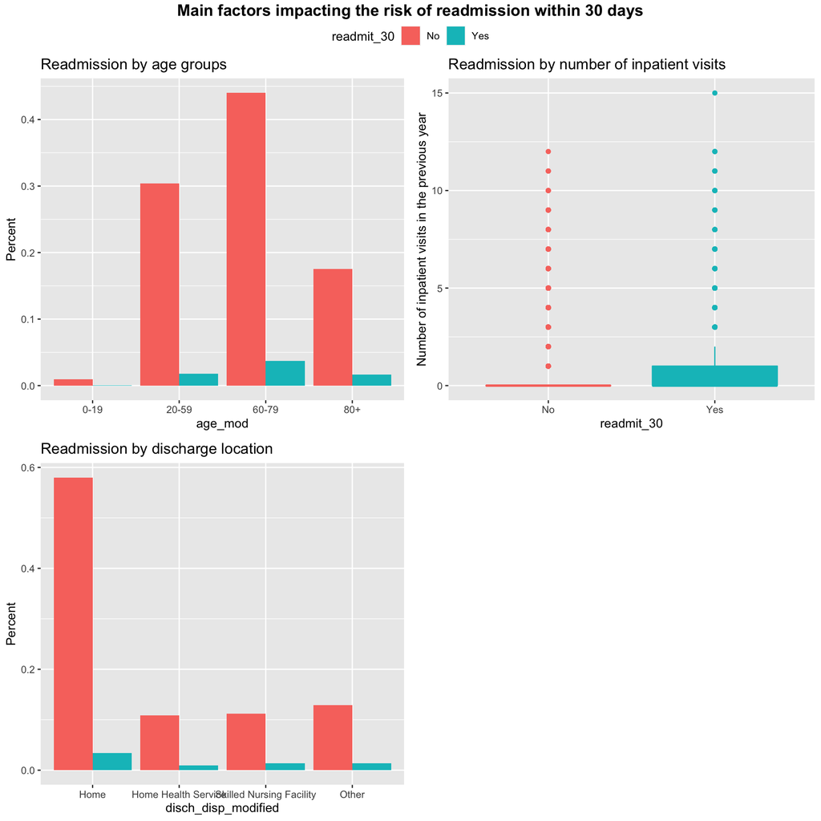

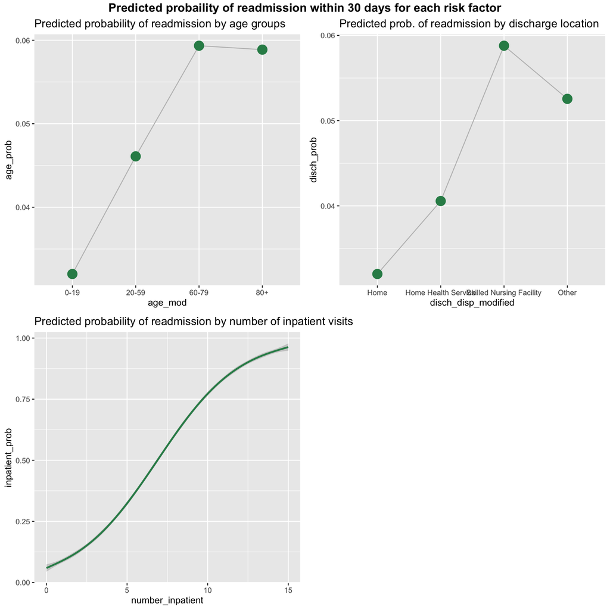

## Limitations and conclusion

Our model identified advanced age, number of inpatient hospitalizations within the past year, and discharge location as being predictive of readmission within 30 days. While many of these risk factors are not inherently modifiable, they can be used to target individuals for additional support. Post-discharge outpatient care and educating patients about disease management could be cost-effective ways to reduce readmission in at-risk patients, including those over the age of 60 and those with a history of recent inpatient admissions. The fact that discharge to home appears to be protective of readmission may reflect the relative lack of disease severity in these patients, but may also provide an interesting avenue of further research to explore what type of post-discharge supports the prevention of readmission.

One important limitation of our study is the predictive ability of our model itself; while it has a low error rate in terms of misclassifying patients, it does not identify many patients who go on to be readmitted. Other limitations of our study include lack of predictors that were either not captured in the study, such as medical insurance information and patients’ socioeconomic status, or not useable due to incompleteness, such as blood tests. Furthermore, [the hospitals sampled are not evenly distributed across the United States](https://www.hindawi.com/journals/bmri/2014/781670/#supplementary-materials), with a strong over representation of Northeastern states, potentially limiting generalizability.

# Detailed process of the analysis

## Data Summary /EDA

These data were collected by the [Center for Clinical and Translational Research](https://archive.ics.uci.edu/ml/datasets/Diabetes+130-US+hospitals+for+years+1999-2008) at Virginia Commonwealth University from 130 hospitals between 1999 and 2008. A detailed description of each variable and the initial data cleaning, undertaken by course instructors, is provided in the Appendix below.

### Numerical summary

After initial cleaning, our dataset contained the following:

Data summary

| Name | readmit_data |
| --- | --- |
| Number of rows | 101766 |
| Number of columns | 32 |
| _______________________ |  |
| Column type frequency: |  |
| factor | 24 |
| numeric | 8 |
| ________________________ |  |
| Group variables | None |

**Variable type: factor**

| skim_variable | n_missing | complete_rate | ordered | n_unique | top_counts |
| --- | --- | --- | --- | --- | --- |
| encounter_id | 0 | 1.00 | FALSE | 101766 | 125: 1, 157: 1, 166: 1, 282: 1 |
| patient_nbr | 0 | 1.00 | FALSE | 71518 | 887: 40, 431: 28, 166: 23, 231: 23 |
| race | 2273 | 0.98 | FALSE | 5 | Cau: 76099, Afr: 19210, His: 2037, Oth: 1506 |
| gender | 3 | 1.00 | FALSE | 2 | Fem: 54708, Mal: 47055 |
| max_glu_serum | 96420 | 0.05 | FALSE | 3 | Nor: 2597, >20: 1485, >30: 1264 |
| A1Cresult | 84748 | 0.17 | FALSE | 3 | >8: 8216, Nor: 4990, >7: 3812 |
| metformin | 0 | 1.00 | FALSE | 4 | No: 81778, Ste: 18346, Up: 1067, Dow: 575 |
| glimepiride | 0 | 1.00 | FALSE | 4 | No: 96575, Ste: 4670, Up: 327, Dow: 194 |
| glipizide | 0 | 1.00 | FALSE | 4 | No: 89080, Ste: 11356, Up: 770, Dow: 560 |
| glyburide | 0 | 1.00 | FALSE | 4 | No: 91116, Ste: 9274, Up: 812, Dow: 564 |
| pioglitazone | 0 | 1.00 | FALSE | 4 | No: 94438, Ste: 6976, Up: 234, Dow: 118 |
| rosiglitazone | 0 | 1.00 | FALSE | 4 | No: 95401, Ste: 6100, Up: 178, Dow: 87 |
| insulin | 0 | 1.00 | FALSE | 4 | No: 47383, Ste: 30849, Dow: 12218, Up: 11316 |
| change | 0 | 1.00 | FALSE | 2 | No: 54755, Ch: 47011 |
| diabetesMed | 0 | 1.00 | FALSE | 2 | Yes: 78363, No: 23403 |
| disch_disp_modified | 0 | 1.00 | FALSE | 4 | Dis: 60234, Oth: 14676, Dis: 13954, Dis: 12902 |
| adm_src_mod | 0 | 1.00 | FALSE | 4 | Eme: 57494, Phy: 29565, Oth: 7926, Tra: 6781 |
| adm_typ_mod | 0 | 1.00 | FALSE | 4 | Eme: 53990, Ele: 18869, Urg: 18480, Oth: 10427 |
| age_mod | 0 | 1.00 | FALSE | 4 | 60-: 48551, 20-: 32373, 80+: 19990, 0-1: 852 |
| diag1_mod | 0 | 1.00 | FALSE | 24 | Oth: 47056, 428: 6862, 414: 6581, 786: 4016 |
| diag2_mod | 0 | 1.00 | FALSE | 25 | Oth: 37491, 276: 6752, 428: 6662, 250: 6071 |
| diag3_mod | 1423 | 0.99 | FALSE | 20 | Oth: 42333, 250: 11555, 401: 8289, 276: 5175 |
| readmitted | 0 | 1.00 | FALSE | 3 | NO: 54864, >30: 35545, <30: 11357 |
| readmit_30 | 0 | 1.00 | FALSE | 2 | 0: 90409, 1: 11357 |

**Variable type: numeric**

| skim_variable | n_missing | complete_rate | mean | sd | p0 | p25 | p50 | p75 | p100 | hist |
| --- | --- | --- | --- | --- | --- | --- | --- | --- | --- | --- |
| time_in_hospital | 0 | 1 | 4.40 | 2.99 | 1 | 2 | 4 | 6 | 14 | ▇▅▂▁▁ |
| num_lab_procedures | 0 | 1 | 43.10 | 19.67 | 1 | 31 | 44 | 57 | 132 | ▃▇▅▁▁ |
| num_procedures | 0 | 1 | 1.34 | 1.71 | 0 | 0 | 1 | 2 | 6 | ▇▂▁▁▁ |
| num_medications | 0 | 1 | 16.02 | 8.13 | 1 | 10 | 15 | 20 | 81 | ▇▃▁▁▁ |
| number_outpatient | 0 | 1 | 0.37 | 1.27 | 0 | 0 | 0 | 0 | 42 | ▇▁▁▁▁ |
| number_emergency | 0 | 1 | 0.20 | 0.93 | 0 | 0 | 0 | 0 | 76 | ▇▁▁▁▁ |
| number_inpatient | 0 | 1 | 0.64 | 1.26 | 0 | 0 | 0 | 1 | 21 | ▇▁▁▁▁ |
| number_diagnoses | 0 | 1 | 7.42 | 1.93 | 1 | 6 | 8 | 9 | 16 | ▁▅▇▁▁ |

We are also adding a variable encoding the cumulative number of admissions per patient (`nb_admissions`). While this variable cannot include hospitalizations that were not captured by the team, either because they were outside of the 130 hospitals sampled or prior to 1999, this will provide a longer overview of a particular patients’ health leading up to the admission than the 1-year snapshots collected in the original dataset.

Data summary

| Name | readmit_data[["nb_admissi… |
| --- | --- |
| Number of rows | 101766 |
| Number of columns | 1 |
| _______________________ |  |
| Column type frequency: |  |
| numeric | 1 |
| ________________________ |  |
| Group variables | None |

**Variable type: numeric**

| skim_variable | n_missing | complete_rate | mean | sd | p0 | p25 | p50 | p75 | p100 | hist |
| --- | --- | --- | --- | --- | --- | --- | --- | --- | --- | --- |
| data | 0 | 1 | 1.63 | 1.53 | 1 | 1 | 1 | 2 | 40 | ▇▁▁▁▁ |

### Visual summary

Because logistic regression depends on observations being independent, we subsetted by selecting only one random hospitalization for each individual patient. We will perform further EDA and further modelling on this subsetted sample.

```
## tibble [71,518 × 31] (S3: tbl_df/tbl/data.frame)
##  $ encounter_id       : Factor w/ 101766 levels "12522","15738",..: 4781 5828 67609 17495 2271 1165 18235 19766 61383 2280 ...
##  $ patient_nbr        : Factor w/ 71518 levels "135","378","729",..: 1 2 3 4 5 6 7 8 9 10 ...
##  $ race               : Factor w/ 5 levels "AfricanAmerican",..: 3 3 3 3 1 1 3 3 3 3 ...
##  $ gender             : Factor w/ 2 levels "Female","Male": 1 1 1 1 1 1 1 1 2 1 ...
##  $ time_in_hospital   : int [1:71518] 3 2 4 3 5 6 9 1 14 12 ...
##  $ num_lab_procedures : int [1:71518] 31 49 68 46 49 43 52 47 21 47 ...
##  $ num_procedures     : int [1:71518] 1 1 2 0 0 2 1 5 0 2 ...
##  $ num_medications    : int [1:71518] 14 11 23 20 5 13 16 12 15 18 ...
##  $ number_outpatient  : int [1:71518] 0 0 0 0 0 0 0 0 3 0 ...
##  $ number_emergency   : int [1:71518] 0 0 0 0 0 0 0 0 1 0 ...
##  $ number_inpatient   : int [1:71518] 1 0 0 0 0 1 0 1 2 0 ...
##  $ number_diagnoses   : int [1:71518] 5 3 9 9 3 2 9 7 7 9 ...
##  $ metformin          : Factor w/ 4 levels "Down","No","Steady",..: 3 2 3 3 2 2 2 2 2 2 ...
##  $ glimepiride        : Factor w/ 4 levels "Down","No","Steady",..: 2 2 2 2 3 2 2 2 2 1 ...
```

[output cut: 17 more lines]

```
## [1] 0.07139461
```

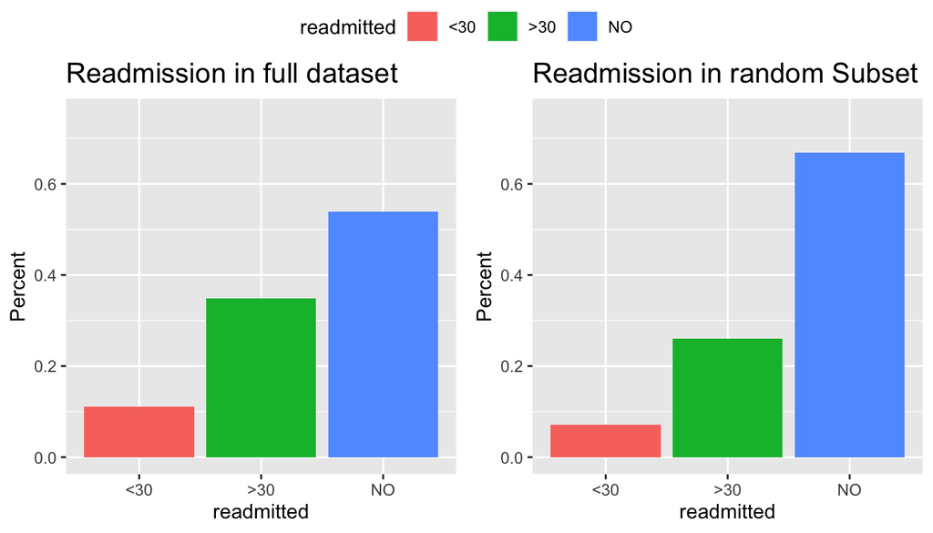

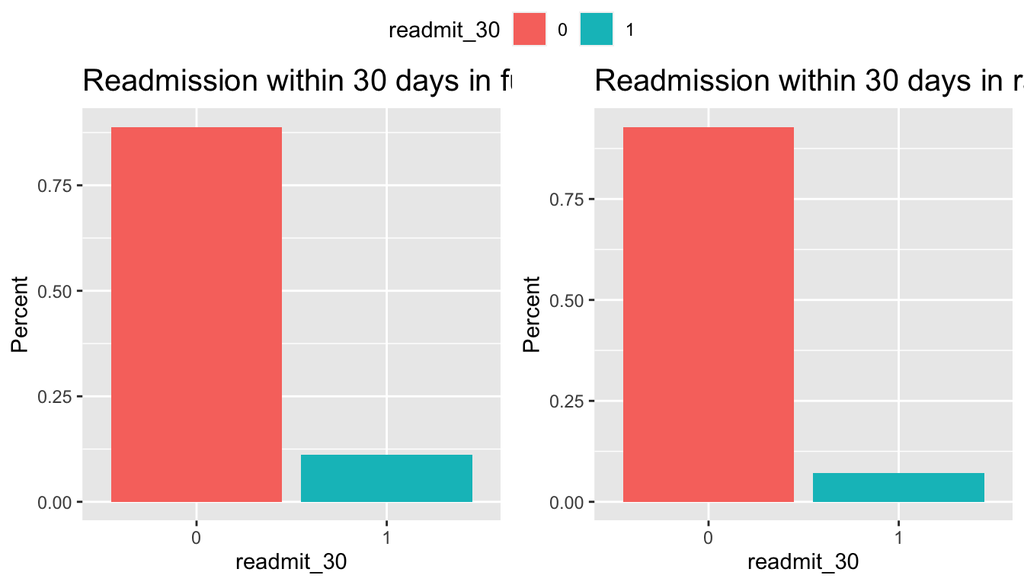

Further exploratory visualizations are performed to obtain an initial sense of which variables may play a role in whether patients are readmitted within 30 days or not:

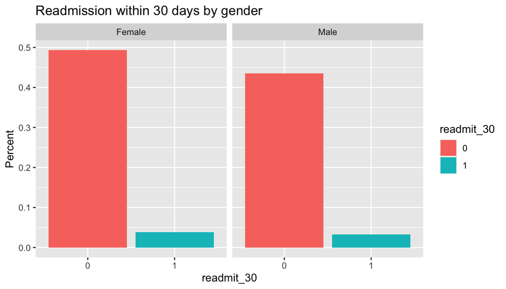

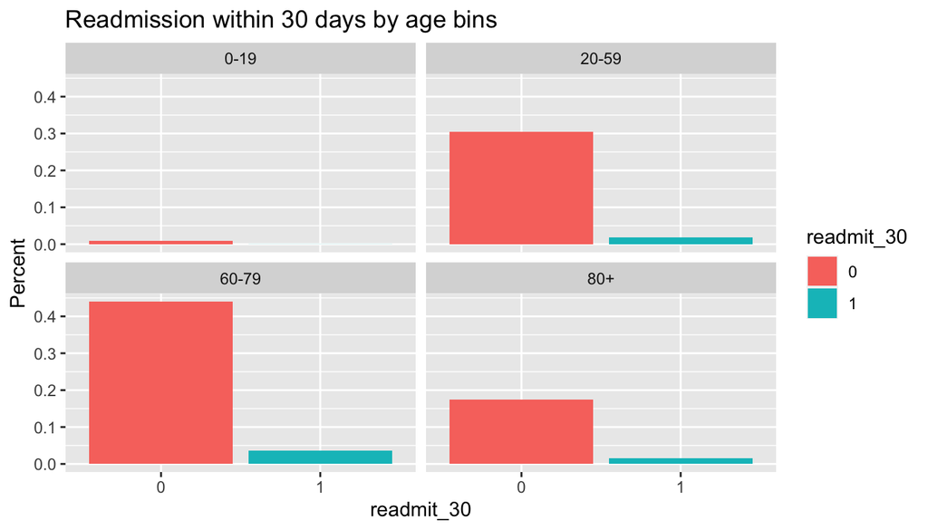

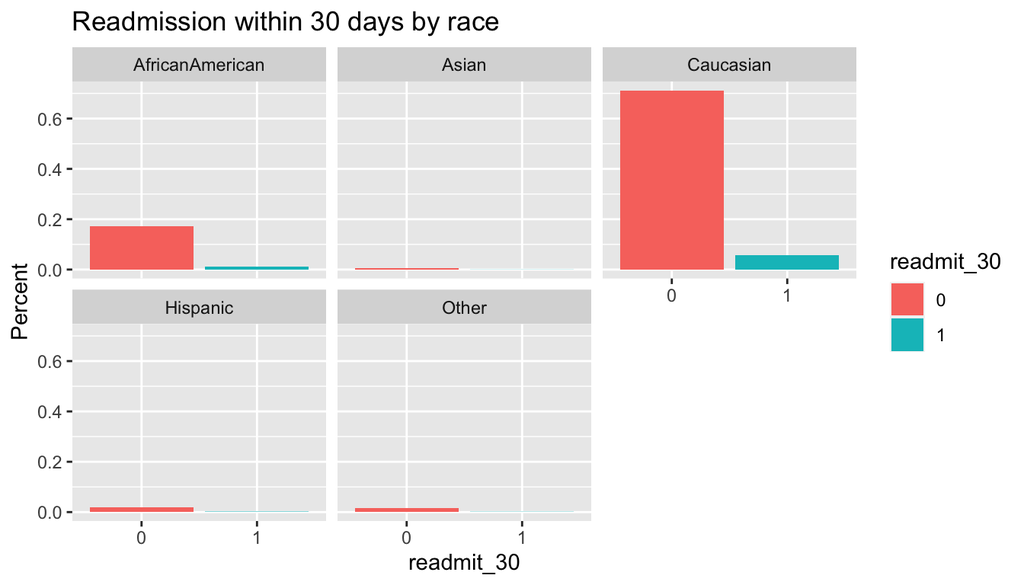

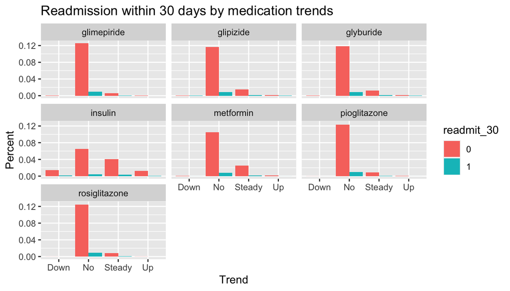

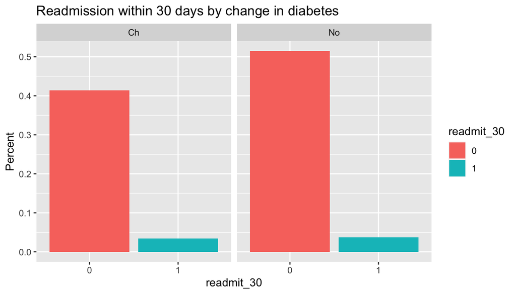

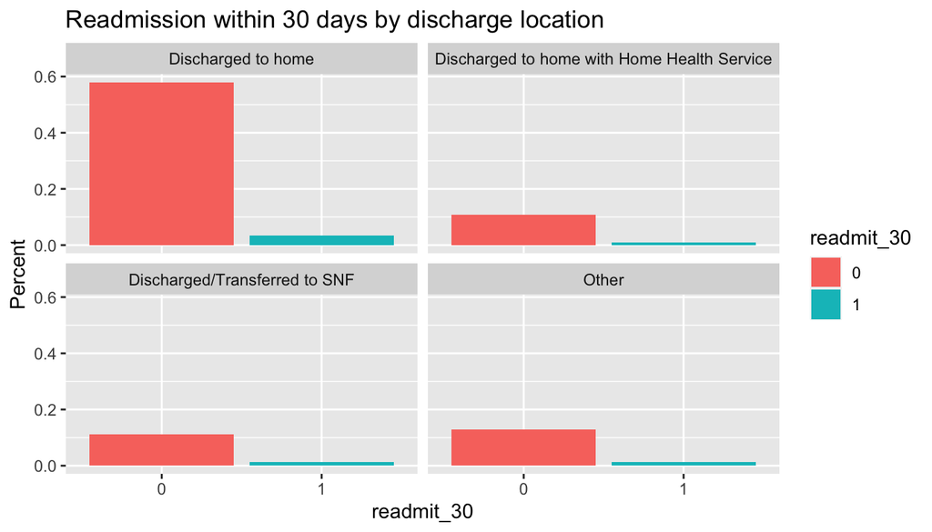

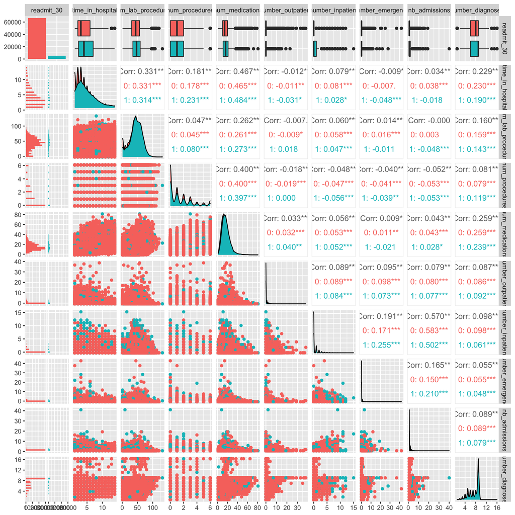

## Analyses

1. First we sought to identify important factors that capture the chance of a readmission within 30 days by creating a model that would describe our dataset. To do so, we subdivided our dataset into `data.train`(60%), `data.test` (20%), and `data.val` (20%), for the most rigorous model evaluation.

To determine which factors play a role in patient readmission < 30 days, we use a `LASSO` approach (`cv.glmnet()`) where the deviance is minimized. Note that rows with NAs are omitted in this process given that the LASSO function does not tolerate these. We will use the training dataset to build the model and the validation subset to evaluate our final model. Because we are using LASSO to select our predictors, a testing dataset will not be necessary, and so we’ll incorporate these data points into the training dataset for this test.

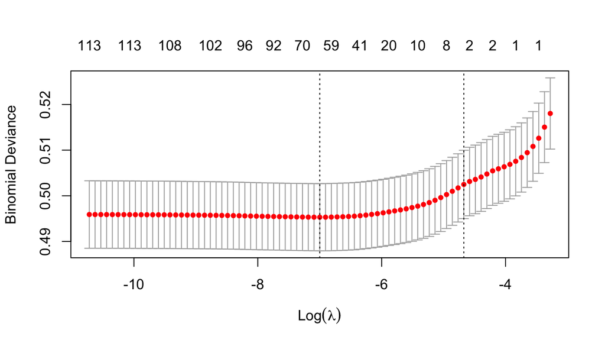

```
## [1] 0.009342585
```

```
## [1] "number_inpatient"
## [2] "disch_disp_modifiedDischarged/Transferred to SNF"
## [3] "disch_disp_modifiedOther"
## [4] "age_mod20-59"
```

Now we use the predictors identified to build our model on the LASSO training subset.

[output not shown]

```
## Analysis of Deviance Table (Type II tests)
##
## Response: readmit_30
##                     LR Chisq Df Pr(>Chisq)
## number_inpatient      770.83  1  < 2.2e-16 ***
## disch_disp_modified   233.73  3  < 2.2e-16 ***
## age_mod                52.85  3  1.977e-11 ***
## ---
## Signif. codes:  0 '***' 0.001 '**' 0.01 '*' 0.05 '.' 0.1 ' ' 1
```

```
##
## Call:
## glm(formula = readmit_30 ~ ., family = binomial, data = data.train.lasso.m)
##
## Deviance Residuals:
##     Min       1Q   Median       3Q      Max
## -1.9609  -0.4187  -0.3274  -0.2874   2.6735
##
## Coefficients:
##                                                                Estimate
## (Intercept)                                                    -3.54526
## number_inpatient                                                0.40359
## disch_disp_modifiedDischarged to home with Home Health Service  0.24592
## disch_disp_modifiedDischarged/Transferred to SNF                0.63617
## disch_disp_modifiedOther                                        0.51747
## age_mod20-59                                                    0.37944
## age_mod60-79                                                    0.64610
## age_mod80+                                                      0.63765
##                                                                Std. Error
## (Intercept)                                                       0.23892
## number_inpatient                                                  0.01363
## disch_disp_modifiedDischarged to home with Home Health Service    0.05206
## disch_disp_modifiedDischarged/Transferred to SNF                  0.04730
## disch_disp_modifiedOther                                          0.04552
## age_mod20-59                                                      0.24105
## age_mod60-79                                                      0.24020
## age_mod80+                                                        0.24224
##                                                                z value Pr(>|z|)
## (Intercept)                                                    -14.839  < 2e-16
## number_inpatient                                                29.610  < 2e-16
## disch_disp_modifiedDischarged to home with Home Health Service   4.724 2.31e-06
## disch_disp_modifiedDischarged/Transferred to SNF                13.451  < 2e-16
## disch_disp_modifiedOther                                        11.367  < 2e-16
## age_mod20-59                                                     1.574  0.11547
## age_mod60-79                                                     2.690  0.00715
## age_mod80+                                                       2.632  0.00848
##
## (Intercept)                                                    ***
## number_inpatient                                               ***
## disch_disp_modifiedDischarged to home with Home Health Service ***
## disch_disp_modifiedDischarged/Transferred to SNF               ***
## disch_disp_modifiedOther                                       ***
## age_mod20-59
## age_mod60-79                                                   **
## age_mod80+                                                     **
## ---
## Signif. codes:  0 '***' 0.001 '**' 0.01 '*' 0.05 '.' 0.1 ' ' 1
##
## (Dispersion parameter for binomial family taken to be 1)
##
##     Null deviance: 29328  on 57212  degrees of freedom
## Residual deviance: 28139  on 57205  degrees of freedom
## AIC: 28155
##
## Number of Fisher Scoring iterations: 5
```

```
## Morgan-Tatar search since family is non-gaussian.
```

```
##   raceAfricanAmerican raceAsian raceCaucasian raceHispanic raceOther genderMale
## 1               FALSE     FALSE         FALSE        FALSE      TRUE      FALSE
## 2               FALSE      TRUE         FALSE        FALSE      TRUE      FALSE
## 3               FALSE     FALSE         FALSE        FALSE      TRUE      FALSE
## 4               FALSE     FALSE         FALSE        FALSE     FALSE      FALSE
## 5               FALSE     FALSE         FALSE         TRUE      TRUE      FALSE
##   age_mod20.59 age_mod60.79 age_mod80. num_medications Criterion
## 1        FALSE         TRUE       TRUE            TRUE  21415.79
## 2        FALSE         TRUE       TRUE            TRUE  21416.92
## 3         TRUE         TRUE       TRUE            TRUE  21417.31
## 4        FALSE         TRUE       TRUE            TRUE  21417.40
## 5        FALSE         TRUE       TRUE            TRUE  21417.42
```

```
##
## Call:  glm(formula = y ~ ., family = family, data = Xi, weights = weights)
##
## Coefficients:
##     (Intercept)        raceOther     age_mod60.79       age_mod80.
##        -3.06538         -0.31728          0.34937          0.54574
## num_medications
##         0.01358
##
## Degrees of Freedom: 41782 Total (i.e. Null);  41778 Residual
## Null Deviance:       21560
## Residual Deviance: 21410     AIC: 21420
```

```
##
## Call:
## glm(formula = readmit_30 ~ race + age_mod + num_medications,
##     family = binomial, data = data.test)
##
## Deviance Residuals:
##     Min       1Q   Median       3Q      Max
## -0.6497  -0.4036  -0.3791  -0.3423   2.9364
##
## Coefficients:
##                 Estimate Std. Error z value Pr(>|z|)
## (Intercept)     -4.43539    0.71657  -6.190 6.03e-10 ***
## raceAsian        0.26701    0.35745   0.747   0.4551
## raceCaucasian    0.17188    0.09197   1.869   0.0616 .
## raceHispanic     0.14429    0.25184   0.573   0.5667
## raceOther        0.08871    0.27229   0.326   0.7446
## age_mod20-59     1.24766    0.71595   1.743   0.0814 .
## age_mod60-79     1.52429    0.71478   2.133   0.0330 *
## age_mod80+       1.51196    0.71682   2.109   0.0349 *
## num_medications  0.01721    0.00368   4.678 2.90e-06 ***
## ---
## Signif. codes:  0 '***' 0.001 '**' 0.01 '*' 0.05 '.' 0.1 ' ' 1
##
## (Dispersion parameter for binomial family taken to be 1)
##
##     Null deviance: 7088.1  on 13904  degrees of freedom
## Residual deviance: 7036.8  on 13896  degrees of freedom
##   (398 observations deleted due to missingness)
## AIC: 7054.8
##
## Number of Fisher Scoring iterations: 6
```

```
## Analysis of Deviance Table (Type II tests)
##
## Response: readmit_30
##                 LR Chisq Df Pr(>Chisq)
## race              3.7708  4  0.4379158
## age_mod          20.0877  3  0.0001628 ***
## num_medications  20.6407  1  5.541e-06 ***
## ---
## Signif. codes:  0 '***' 0.001 '**' 0.01 '*' 0.05 '.' 0.1 ' ' 1
```

`Race` is not significant so we will remove it from the model.

```
## Analysis of Deviance Table (Type II tests)
##
## Response: readmit_30
##                 LR Chisq Df Pr(>Chisq)
## age_mod           24.414  3  2.047e-05 ***
## num_medications   21.701  1  3.186e-06 ***
## ---
## Signif. codes:  0 '***' 0.001 '**' 0.01 '*' 0.05 '.' 0.1 ' ' 1
```

```
## [1] 1
```

2. Now we’ll compare the bestglm and LASSO models’ on AUC/ROC to see which one is best for predicting whether a patient will be a readmit within 30 days.

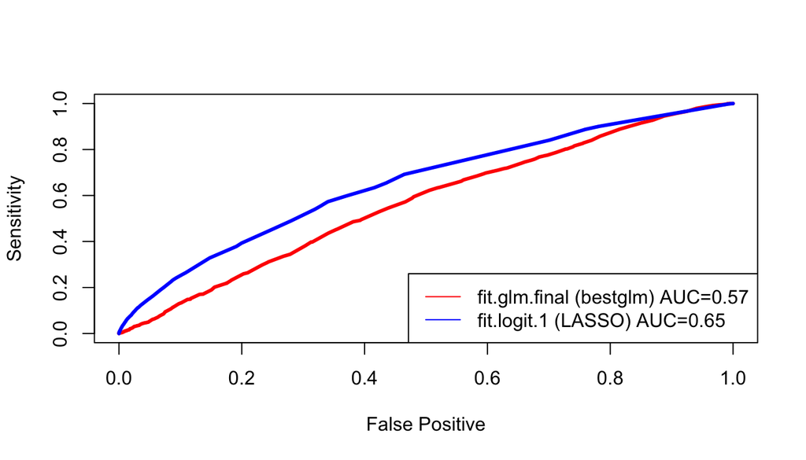

The ROC curve and AUC clearly indicate that our final LASSO model is superior to the bestglm model across thresholds. We’ll next compare prediction using starting with a threshold our probability of readmission at 1/2.

```
## Confusion Matrix and Statistics
##
##           Reference
## Prediction     0     1
##          0 53099  4028
##          1    50    36
##
##                Accuracy : 0.9287
##                  95% CI : (0.9266, 0.9308)
##     No Information Rate : 0.929
##     P-Value [Acc > NIR] : 0.5941
##
##                   Kappa : 0.0144
##
##  Mcnemar's Test P-Value : <2e-16
##
##             Sensitivity : 0.0088583
##             Specificity : 0.9990592
##          Pos Pred Value : 0.4186047
##          Neg Pred Value : 0.9294904
##              Prevalence : 0.0710328
##          Detection Rate : 0.0006292
##    Detection Prevalence : 0.0015032
##       Balanced Accuracy : 0.5039588
##
##        'Positive' Class : 1
##
```

```
## Confusion Matrix and Statistics
##
##           Reference
## Prediction     0     1
##          0 13297  1006
##          1     0     0
##
##                Accuracy : 0.9297
##                  95% CI : (0.9254, 0.9338)
##     No Information Rate : 0.9297
##     P-Value [Acc > NIR] : 0.5084
##
##                   Kappa : 0
##
##  Mcnemar's Test P-Value : <2e-16
##
##             Sensitivity : 0.00000
##             Specificity : 1.00000
##          Pos Pred Value :     NaN
##          Neg Pred Value : 0.92967
##              Prevalence : 0.07033
##          Detection Rate : 0.00000
##    Detection Prevalence : 0.00000
##       Balanced Accuracy : 0.50000
##
##        'Positive' Class : 1
##
```

```
##       Readmission Predicted Readmission       Prob
## 13905           0                     0 0.06732381
## 2983            0                     0 0.06105446
## 4459            0                     0 0.07597799
## 14219           0                     0 0.05050594
## 3764            0                     0 0.09423579
## 12432           1                     0 0.07356953
## 4594            0                     0 0.05953782
## 11491           1                     0 0.08433652
## 9027            1                     0 0.08231862
## 10099           0                     0 0.06783088
```

Comparing on a threshold of 1/2 again confirms that the LASSO-generated model is superior on sensitivity (0.008 vs 0). While the bestglm model has better specificity (1 vs 0.999), it failed to identify any cases of readmission and the LASSO model’s specificity was also very high. Based on its superior ROC, AUC, and balance of sensitivity and specificity, we will proceed with the LASSO-generated model as our final predictive model.

Next we’ll choose threshold that balances sensitivity and specificity of our model. We choose a model with sensitivity of ~60% to maximize our chances of identifying patients at risk for readmission. While this will increase the false positive rate, potentially causing hospitals to spend additional money caring for patients who would not have been readmitted, this is preferable from a health-standpoint.

```
##    threshold specificity sensitivity
## 1 0.06593988   0.6302659    0.597687
```

```
## Confusion Matrix and Statistics
##
##           Reference
## Prediction     0     1
##          0 33498  1635
##          1 19651  2429
##
##                Accuracy : 0.628
##                  95% CI : (0.624, 0.6319)
##     No Information Rate : 0.929
##     P-Value [Acc > NIR] : 1
##
##                   Kappa : 0.0748
##
##  Mcnemar's Test P-Value : <2e-16
##
##             Sensitivity : 0.59769
##             Specificity : 0.63027
##          Pos Pred Value : 0.11001
##          Neg Pred Value : 0.95346
##              Prevalence : 0.07103
##          Detection Rate : 0.04246
##    Detection Prevalence : 0.38593
##       Balanced Accuracy : 0.61398
##
##        'Positive' Class : 1
##
```

3. Provided estimates indicate that **it costs twice as much** to mislabel a readmission than it does to mislabel a non-readmission; therefore we propose a specific classification rule to minimize the cost.

Bayes’ rule can be used as a classification rule to minimize the cost according to specific weights. Assuming the cost of misclassifying “1” to “0” is 2 times of that of misclassifying “0” to “1”, then the Bayes rule is thresholding over the
$$\hat P(Y=1 \vert x) > \frac{0.5}{(1+0.5)}=0.333$$

Therefore we’ll use Bayes thresholding on our final model:

```
## [1] 0.1420656
```

```
## Confusion Matrix and Statistics
##
##           Reference
## Prediction     0     1
##          0 52955  3967
##          1   194    97
##
##                Accuracy : 0.9273
##                  95% CI : (0.9251, 0.9294)
##     No Information Rate : 0.929
##     P-Value [Acc > NIR] : 0.9433
##
##                   Kappa : 0.0354
##
##  Mcnemar's Test P-Value : <2e-16
##
##             Sensitivity : 0.023868
##             Specificity : 0.996350
##          Pos Pred Value : 0.333333
##          Neg Pred Value : 0.930308
##              Prevalence : 0.071033
##          Detection Rate : 0.001695
##    Detection Prevalence : 0.005086
##       Balanced Accuracy : 0.510109
##
##        'Positive' Class : 1
##
```

4. Finally, we evaluate our final model with the validation data to give an honest assessment of its predictive ability. To do so, we will calculate AUC and MCE on our `data.val` subset and threshold our classification at 33.3% risk, per Bayes rule.

```
## Area under the curve: 0.6488
```

```
## Confusion Matrix and Statistics
##
##           Reference
## Prediction     0     1
##          0 13413   852
##          1    28    12
##
##                Accuracy : 0.9385
##                  95% CI : (0.9344, 0.9424)
##     No Information Rate : 0.9396
##     P-Value [Acc > NIR] : 0.7199
##
##                   Kappa : 0.0213
##
##  Mcnemar's Test P-Value : <2e-16
##
##             Sensitivity : 0.0138889
##             Specificity : 0.9979168
##          Pos Pred Value : 0.3000000
##          Neg Pred Value : 0.9402734
##              Prevalence : 0.0603985
##          Detection Rate : 0.0008389
##    Detection Prevalence : 0.0027962
##       Balanced Accuracy : 0.5059029
##
##        'Positive' Class : 1
##
```

```
## [1] 0.1210765
```

Our model fits the validation data similarly to the training data with AUC=0.648 and predicts with a similar accuracy (training MCE=0.1420656, validation MCE=0.1210765). Overall, our model can predict readmission in our validation sample with low sensitivity (0.0138) and but high specificity (0.999).

# Conclusion

Our model identified advanced age, number of inpatient hospitalizations within the past year, and discharge location as being predictive of readmission within 30 days. While many of these risk factors are not inherently modifiable, they can be used to target individuals for additional support. Post-discharge outpatient care and educating patients about disease management could be cost-effective ways to reduce readmission in at-risk patients, including those over the age of 60 and those with a history of recent inpatient admissions.

In particular, our model indicates that patients who are readmitted to inpatient care are most likely to require readmission within 30 days. This could be an indication of greater disease severity in these individuals, requiring frequent hospitalization, but could also be influenced by the ability of patients to manage their disease outside the hospital. As a chronic condition, diabetes requires vigilant symptom management on the part of patients. One could imagine that patients who do not have access to regular blood-glucose testing or healthy food options may struggle to keep symptoms under control, leading to readmission. Similarly, access to stable and regular outpatient care could support patients in managing their symptoms and provide monitoring from providers who could intervene before a patient would require hospitalization. While one may argue that this is counter to our finding that discharge to home is protective against readmission, there are several possible explanations. Firstly, patients with less severe disease are more likely to be discharged home than more critically ill patients, reducing the overall incidence of readmission in home-discharged individuals. Furthermore, our data does not capture any of the benefits that individuals discharged to home may have, including outpatient provider access or strong family supports. Future studies could explore this possibility by surveying patient attitudes towards and knowledge about diabetes management, access to necessary medical supplies and nutrition options, and support of family and medical providers.

One important limitation of our study is the predictive ability of our model itself; while it had a low misclassification error rate (MCE) (0.1210765), sensitivity was also low, capturing only about 1% of readmitted subjects. This indicates that there are likely latent factors not included in our dataset that are influencing readmission.

Other limitations of our study include missing data points, particularly among biological measures such as serum glucose and HbA1c, which could provide direct and unbiased assessments of patients’ diabetes severity. HbA1c in particular is indicative of blood glucose levels over several months and could provide important insight into the health status of individuals at readmission. Other potentially important predictors include medical insurance information and patients’ socioeconomic status, which unfortunately can have strong determinations in a patients’ access to care and therefore can potentially predict health status. Finally, while the dataset is large, [the hospitals sampled are not evenly distributed across the United States](https://www.hindawi.com/journals/bmri/2014/781670/#supplementary-materials), with a strong over representation of Northeastern states. Therefore, these results could be disproportionately influenced by the healthcare environment of the Northeast (including treatment norms, insurance standards, or state law) and should be generalized with caution.

# Appendix

### Initial Data Cleaning and Description of Variables

The following descriptions were provided by the course instructors, who also undertook initial data cleaning. Three former students Spencer Luster, Matthew Lesser and Mridul Ganesh, identified the original dataset, which includes the following variables:

**1) Patient identifiers:** a. `encounter_id`: unique identifier for each admission b. `patient_nbr`: unique identifier for each patient **2) Patient Demographics:** `race`, `age`, `gender`, `weight` cover the basic demographic information associated with each patient. `Payer_code` is an additional variable that identifies which health insurance (Medicare /Medicaid / Commercial) the patient holds. **3) Admission and discharge details:** a. `admission_source_id` and `admission_type_id` identify who referred the patient to the hospital (e.g. physician vs. emergency dept.) and what type of admission this was (Emergency vs. Elective vs. Urgent). b. `discharge_disposition_id` indicates where the patient was discharged to after treatment. **4) Patient Medical History:** a. `num_outpatient`: number of outpatient visits by the patient in the year prior to the current encounter b. `num_inpatient`: number of inpatient visits by the patient in the year prior to the current encounter c. `num_emergency`: number of emergency visits by the patient in the year prior to the current encounter **5) Patient admission details:** a. `medical_specialty`: the specialty of the physician admitting the patient b. `diag_1`, `diag_2`, `diag_3`: ICD9 codes for the primary, secondary and tertiary diagnoses of the patient. ICD9 are the universal codes that all physicians use to record diagnoses. There are various easy to use tools to lock up what individual codes mean (Wikipedia is pretty decent on its own) c. `time_in_hospital`: the patient’s length of stay in the hospital (in days) d. `number_diagnoses`: Total no. of diagnosis entered for the patient e. `num_lab_procedures`: No. of lab procedures performed in the current encounter f. `num_procedures`: No. of non-lab procedures performed in the current encounter g. `num_medications`: No. of distinct medications prescribed in the current encounter **6) Clinical Results:** a. `max_glu_serum`: indicates results of the glucose serum test b. `A1Cresult`: indicates results of the A1c test **7) Medication Details:** a. `diabetesMed`: indicates if any diabetes medication was prescribed b. `change`: indicates if there was a change in diabetes medication c. `24 medication variables`: indicate whether the dosage of the medicines was changed in any manner during the encounter **8) Readmission indicator:** Indicates whether a patient was readmitted after a particular admission. There are 3 levels for this variable: “NO” = no readmission, “< 30” = readmission within 30 days and “> 30” = readmission after more than 30 days.

The course instructors completed the first level of data cleaning, as described below:

1. `Payer code`, `weight` and `Medical Specialty` were removed since they have a large number of missing values.
2. Variables such as `acetohexamide`, `glimepiride.pioglitazone`, `metformin.rosiglitazone`, `metformin.pioglitazone` had little variability, and are as such excluded. This also includes the following variables: `chlorpropamide`, `acetohexamide`, `tolbutamide`, `acarbose`, `miglitor`, `troglitazone`, `tolazamide`, `examide`, `citoglipton`, `glyburide.metformin`, `glipizide.metformin`, and `glimepiride.pioglitazone`.
3. Some categorical variables were binned For example, `Diag1_mod` keeps some original levels with large number of patients and aggregates other patients as `others`.